# Eksploracja danych z Centrum Nauki Kopernik. Projekt 1 Faza 2

Konrad Czechowski, Karolina Gajewska, Iwona Majewska

13 kwietnia 2016

## Wstęp

Jako cel fazy drugiej projektu wybraliśmy segmentację odwiedzających Centrum Nauki Kopernik. Z dostępnego zbioru danych wyodrębniliśmy próbki o liczebności 2000 a następnie przeprowadziliśmy na nich niezależnie analizę segmentacji. Próbki grupowaliśmy między innymi na fakt zajścia interakcji między odwiedzającym a eksponatem, jak również ze względu na czas owej interakcji. Przeprowadzona analiza pokazała, że wyniki segmentacji odwiedzających nie są jednoznaczne.

## Przygotowanie danych

W drugiej fazie projektu analizę oparliśmy na danych przygotowanych już w fazie pierwszej. Dla przypomnienia : każdej parze odwiedzający - eksponat przypisaliśmy najdłuższy czas interakcji odwiedzającego z eksponatem. W przypadkach gdy odwiedzający nie odwiedził eksponatu, przypisywany był mu zerowy czas interakcji. Z otrzymanego zbioru wylosowaliśmy następnie 4000 obserwacji, otrzymaną próbkę podzieliliśmy następnie na dwie próbki po 2000 obserwacji.

```
## [1] 10000    59
```

```r
set.seed(181)
n <- 4000
ix <- sample.int(10000, n)
ix1 <- ix[1:(n/2)]
ix2 <- ix[(n/2+1):n]

st.sec <- st
st.sec[is.na(st.sec)] <- 0
df1 <- st.sec[ix1,]
df2 <- st.sec[ix2,]
df <- rbind(df1, df2)
d <- as.matrix(dist(df))
dist.between <- d[1:(n/2), (n/2+1):n]
```

## Grupowanie ze względu na czas interakcji z eksponatem

Dla wylosowanych próbek przeprowadziliśmy klastrowania metodą kmeans na 6 grup. Następnie sprawdziliśmy, jak zbliżone do siebie są te klastrowania.

```r
clust11 <- kmeans(df1, centers = 6)
clust12 <- kmeans(df2, centers = 6)
c1 <- clust11$cluster
c2 <- clust12$cluster
```

Zmienna matching informuje nas o numerach dopasowanych klastrów dla obu próbek danych. Zmienna nmatches zwraca liczbę dopasowanych klastrów. Jako ostatni podawany jest ułamek danych dopasowanych do siebie.

```
## $matching
##      clustering 1 clustering 2
## [1,] "3"          "4"
## [2,] "5"          "5"
##
## $nmatches
## [1] 2
##
## $data.matched
## [1] 0.778
```

Do sprawdzenia jakości poszczególnych klastrowań wykorzystaliśmy sylwetki. Poniżej znajdują się wykresy sylwetek odpowiednio dla pierwszego i drugiego klastrowania.

```
##   cluster size ave.sil.width
## 1       1  227         -0.21
## 2       2   33          0.16
## 3       3 1558          0.56
## 4       4   27         -0.03
## 5       5   43          0.23
## 6       6  112         -0.17
```

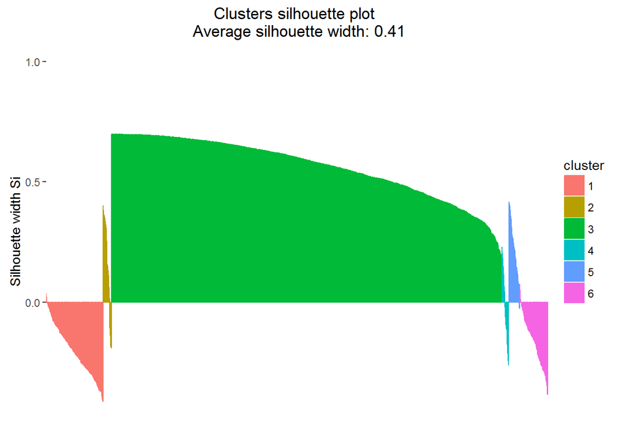

```
##   cluster size ave.sil.width
## 1       1   99         -0.14
## 2       2  249         -0.21
## 3       3   24         -0.05
## 4       4 1544          0.54
## 5       5   51          0.28
## 6       6   33         -0.05
```

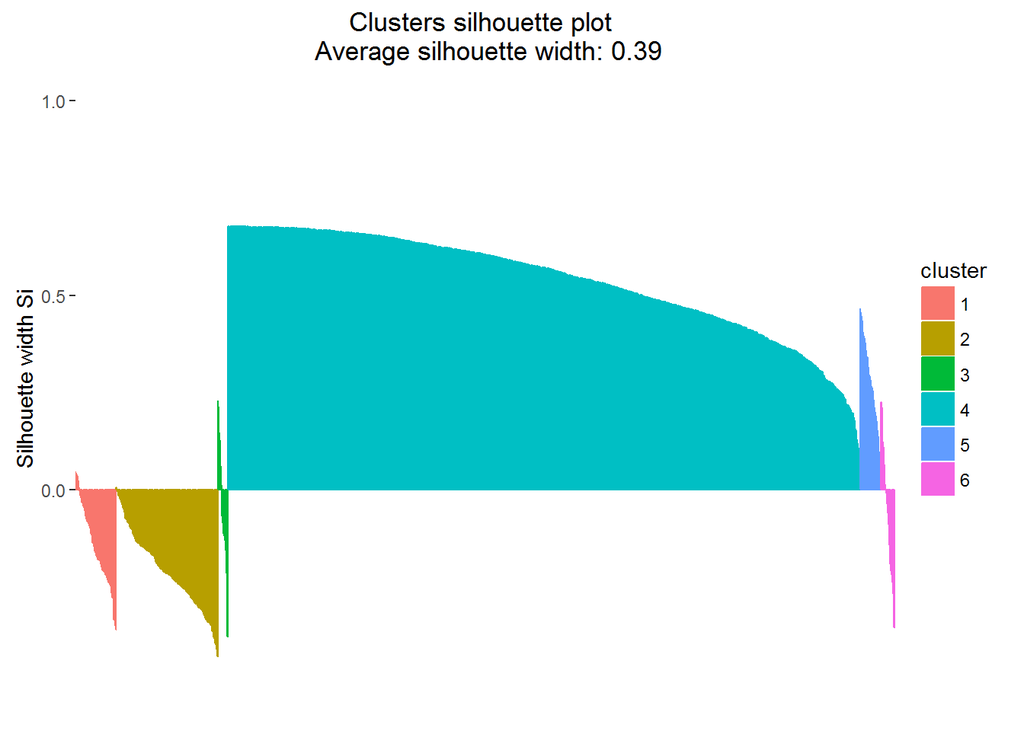

Z wykresów sylwetek wynika, że w przypadku pierwszego grupowania obiekty z klastrów 1, 4 i 6 mają bliżej do sąsiednich klastrów. Najwyraźniej wybrana liczba klastrów: 6 jest za duża. Podobny wniosek można wysnuć z analizy sylwetek dla drugiego grupowania.

Przeprowadziliśmy obliczenia dla liczby klastrów równej 2.

```r
clust11 <- kmeans(df1, centers = 2)
clust12 <- kmeans(df2, centers = 2)
c1 <- clust11$cluster
c2 <- clust12$cluster
```

```
## $matching
##      clustering 1 clustering 2
## [1,] "1"          "1"
##
## $nmatches
## [1] 1
##
## $data.matched
## [1] 0.86775
```

Aby wizualnie ocenić sensowność klastrowania, zrzutowaliśmy dane wejściowe na przestrzeń dwuwymiarową. Skorzystaliśmy z funkcji cmdscale.

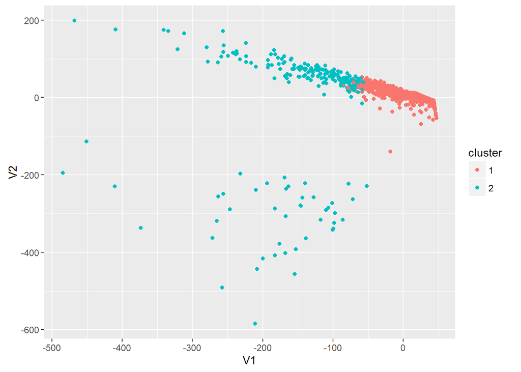

Otrzymaliśmy dwa klastry, z których jeden jest istotnie większy od drugiego. Rzutowanie przestrzenne wskazuje na to, że klastrowanie nie wyróżniło czytelnych dwóch grup.

Można postawić hipotezę, że dane wejścione nie dzielą się na grupy w jasny sposób.

## Grupowanie ze względu na wystąpienie interakcji z eksponatem

Następnie przeprowadziliśmy klastrowanie zbioru danych, w którym każdej parze odwiedzający - stacja przyporządkowaliśmy wartość 1, jeśli odwiedzający wszedł w interakcję ze stacją i 0 w przeciwnym przypadku. Użyliśmy analogicznych kodów, dlatego poniżej podajemy tylko wyniki porównania klastrowań i sylwetki.

```
## $matching
##      clustering 1 clustering 2
## [1,] "4"          "2"
## [2,] "5"          "3"
##
## $nmatches
## [1] 2
##
## $data.matched
## [1] 0.562
```

```
##   cluster size ave.sil.width
## 1       1  227         -0.06
## 2       2  226         -0.15
## 3       3   91         -0.10
## 4       4  427          0.17
## 5       5  818          0.09
## 6       6  211         -0.11
```

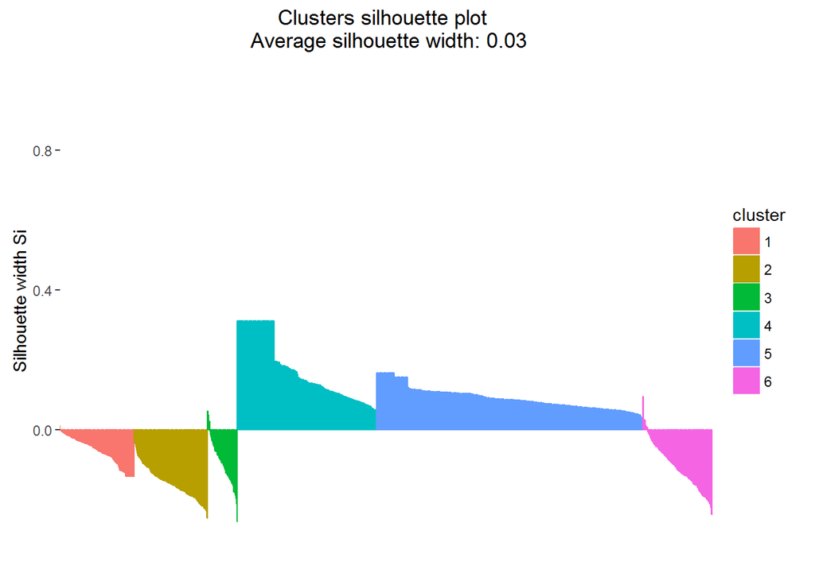

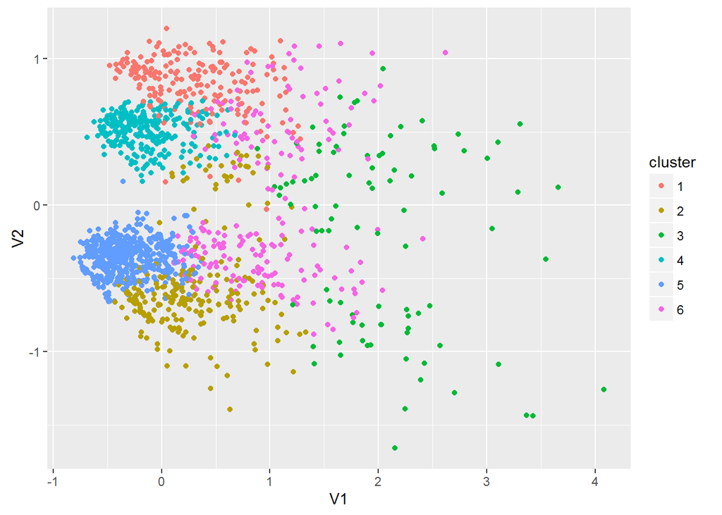

Zarówno wykresy sylwetek, jak i przeskalowane dane sugerują, że nie ma naturalnego grupowania danych.

## Grupowanie ze względu na wystąpienie długiej interakcji z eksponatem

Przeprowadziliśmy też klastrowanie danych, w których parze odwiedzający - stacja została przyporządkowana wartość 1, gdy odwiedzający wszedł w interakcję ze stacją i trwała ona dłużej niż mediana czasów wszystkich interakcji z daną stacją.

```
## $matching
##      clustering 1 clustering 2
## [1,] "5"          "3"
## [2,] "6"          "4"
##
## $nmatches
## [1] 2
##
## $data.matched
## [1] 0.715
```

```
##   cluster size ave.sil.width
## 1       1  153         -0.14
## 2       2  153         -0.17
## 3       3   66         -0.13
## 4       4   82         -0.18
## 5       5  349          0.06
## 6       6 1197          0.39
```

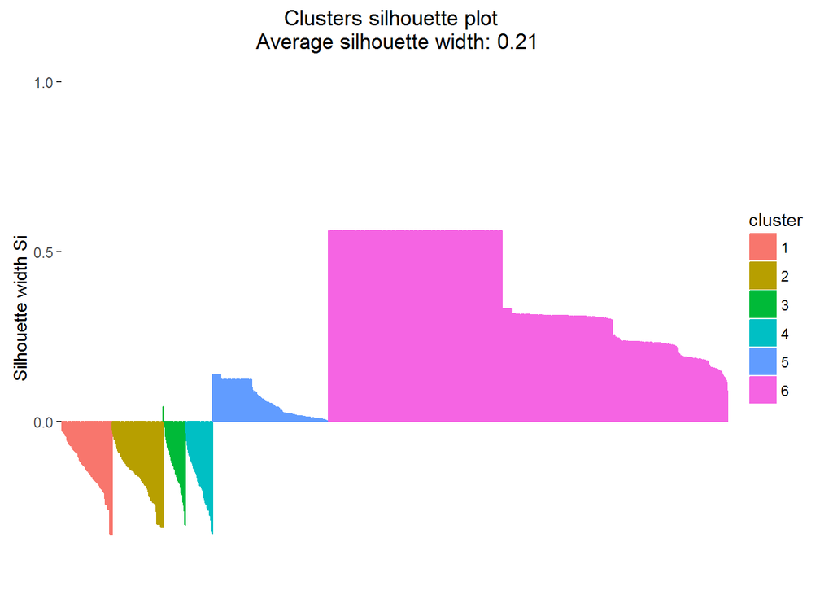

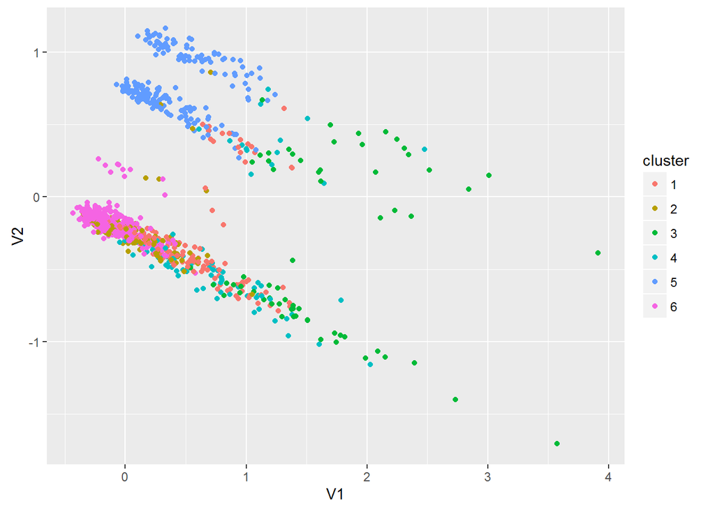

## Wnioski

1. Segmentacja odwiedzających Centrum Nauki Kopernik nie jest łatwym zadaniem ze względu na mnogość eksponatów i brak wyraźnego wzorca zwiedzania.
2. Próby grupowania danych najczęściej prowadzą do otrzymania jednego klastra istotnie większego od innych. Sugeruje to trudności w wyróżnianiu grup zwiedzających.
3. W następnym etapie projektu można rozważyć ograniczenie zbioru zwiedzających, na przykład do osób, które odwiedziły stosunkowo dużo stacji lub spędziły na stacjach średnio więcej czasu.